# Regression - HW2

Fall 2019

### The broad steps of Machine learning in R.

1. Split the data into training and test. Set test aside.
2. Fit a good model to the training data.
3. See how your model did on the training data.
4. Test how your model performs on the test data.

# Regression

1. Split data into training and test set (75% in train set, 25% in test set)

```r
set.seed(151)
airquality_split = sample.split(airquality, SplitRatio = 0.75)
train_regression = subset(airquality, airquality_split == TRUE)
test_regression = subset(airquality, airquality_split == FALSE)
```

### Linear Regression

- Assumes a linear relationship.
- Independent variables should not be correlated (no mulitcollinearity)
- The number of observations should be greater than the number of independent variables.

We will predict the response of the Temperature based on Wind.

This is the data we will fit a linear model to.

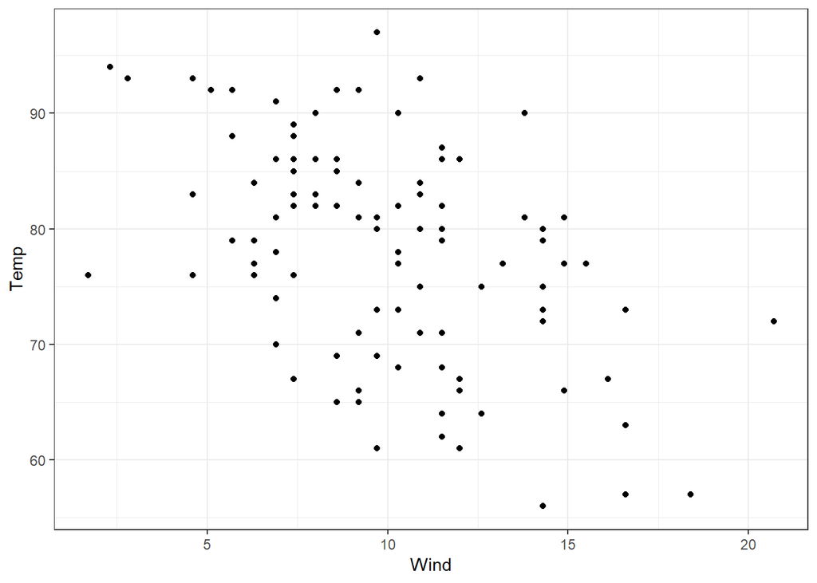

```r
ggplot(data = train_regression) + geom_point(aes(x=Wind, y=Temp)) + theme_bw()
```

2. Create and fit a linear model to predict Temperature from Wind using the training set

```r
#help(train)
linear_regression <- train(Temp ~ Wind, data = train_regression, method = "lm")
summary(linear_regression)
```

```
##
## Call:
## lm(formula = .outcome ~ ., data = dat)
##
## Residuals:
##     Min      1Q  Median      3Q     Max
## -17.279  -6.399   1.721   6.175  18.721
##
## Coefficients:
##             Estimate Std. Error t value Pr(>|t|)
## (Intercept)  90.0343     2.4911  36.143  < 2e-16 ***
## Wind         -1.2119     0.2347  -5.164 1.25e-06 ***
## ---
## Signif. codes:  0 '***' 0.001 '**' 0.01 '*' 0.05 '.' 0.1 ' ' 1
##
## Residual standard error: 8.316 on 99 degrees of freedom
## Multiple R-squared:  0.2122, Adjusted R-squared:  0.2042
## F-statistic: 26.67 on 1 and 99 DF,  p-value: 1.252e-06
```

3. Vizualize how your model performed on the train data by plotting the regression line on top of the train data points.

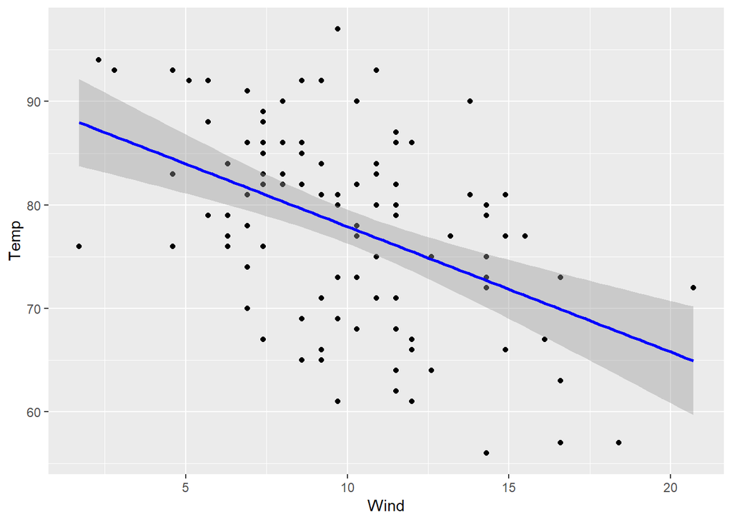

```r
ggplot(data = train_regression) + geom_point(aes(x=Wind, y=Temp)) + stat_smooth(method = "lm",aes(x=Wind, y=Temp), color = 'blue')
```

4. Explore how the model performs on the test data. For Linear Regression:
- The residuals should be close to zero.
- There should be equal variance around the regression line (homoscedasticity).
- Residuals should be normally distributed.
- Independent variables and residuals should not be correlated.

4 a) See how the model performs on the test data

```r
#help(predict)
linear_predict <- predict(linear_regression, newdata = test_regression)
```

4 b) Look at the residuals. Are they close to zero?

```r
#look at the median residual value. Close to zero is best
#help(summary)
summary(resid(linear_regression))
```

```
##    Min. 1st Qu.  Median    Mean 3rd Qu.    Max.
## -17.279  -6.399   1.721   0.000   6.175  18.721
```

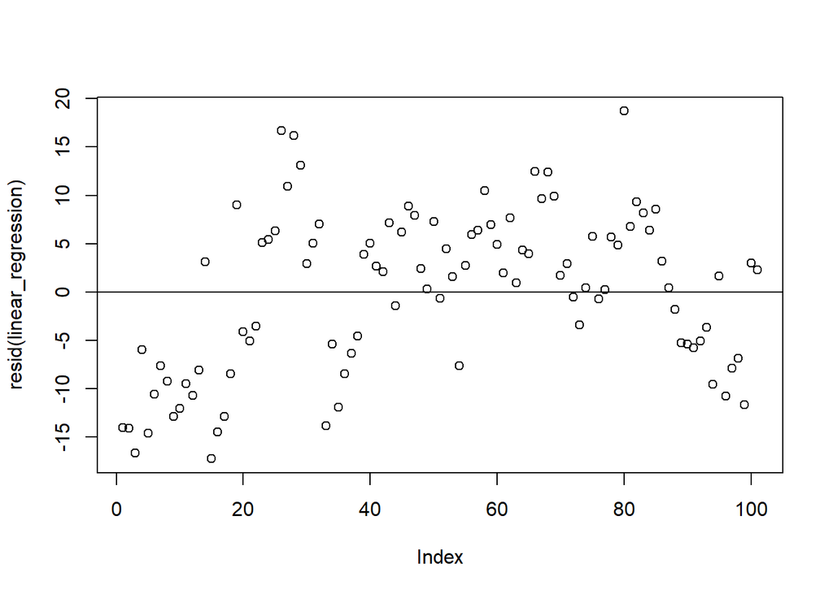

```r
plot(resid(linear_regression))
abline(0,0)
```

No. Majority of them are not close to zero; Median is 1.721, somewhat close to zero but not very.

4 c) Plot predicted temperature vs observed temperature. A strong model should show a strong correlation

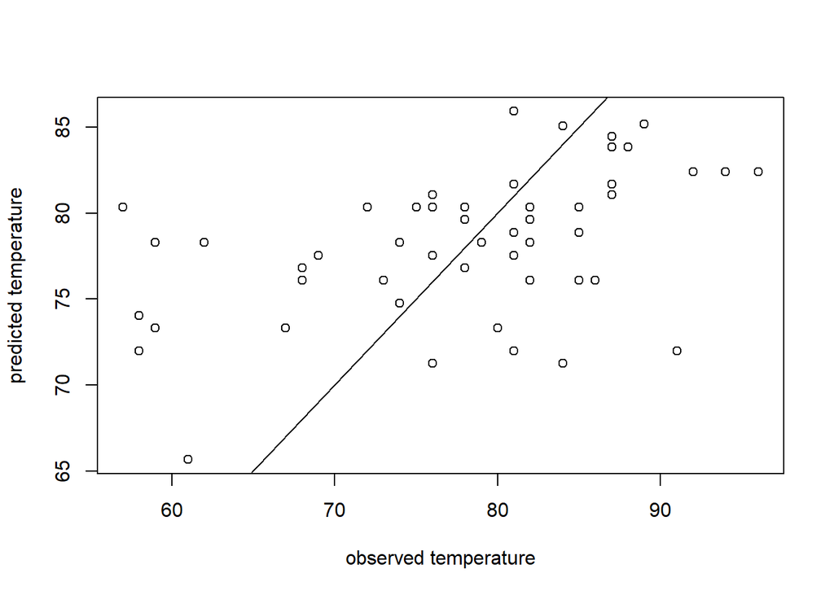

```r
plot(test_regression$Temp,linear_predict, xlab = 'observed temperature', ylab = 'predicted temperature')
abline(0,1)
```

```r
cor.test(test_regression$Temp,linear_predict)
```

```
##
##  Pearson's product-moment correlation
##
## data:  test_regression$Temp and linear_predict
## t = 3.6033, df = 50, p-value = 0.0007226
## alternative hypothesis: true correlation is not equal to 0
## 95 percent confidence interval:
##  0.2067489 0.6467913
## sample estimates:
##       cor
## 0.4540319
```

Moderate correlation, statistically significant.

4 d) Visualize the predicted values in relation to the real data points. Look for homoscedasticity

```r
# Extract coefficients from the model
coeffs <- linear_regression$finalModel$coefficients
coeffs
```

```
## (Intercept)        Wind
##   90.034320   -1.211893
```

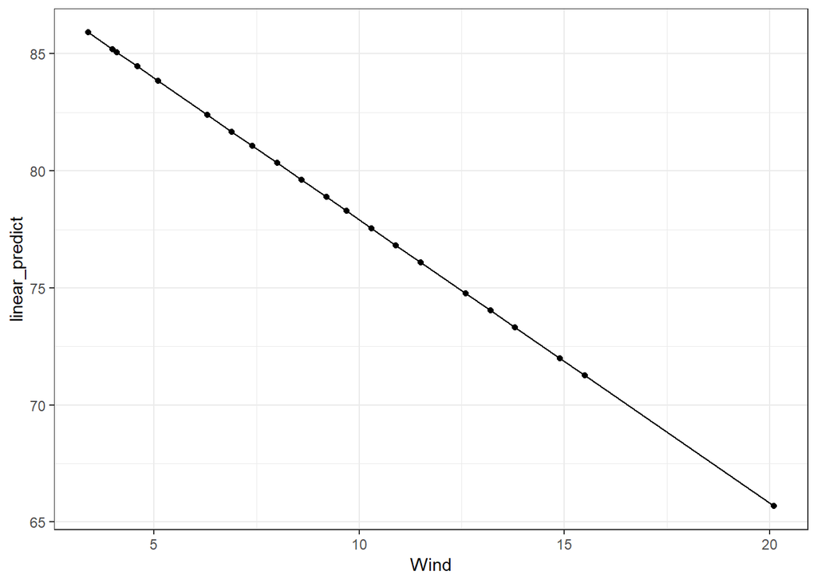

```r
# plot the regression line on the predicted values

test_predict_compare <- cbind(test_regression,linear_predict)
ggplot(data = test_predict_compare) + geom_point(aes(x=Wind, y=linear_predict)) + geom_line(aes(x=Wind, y=coeffs[1]+Wind*coeffs[2])) + theme_bw()
```

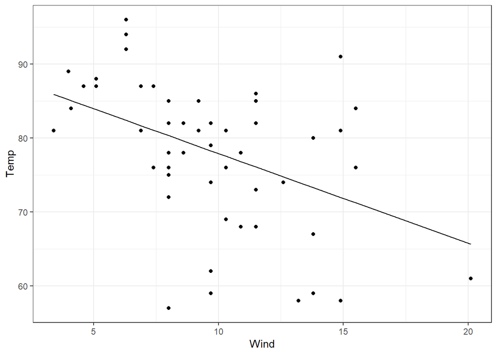

```r
# plot the original test values
ggplot(data = test_predict_compare) + geom_point(aes(x=Wind, y=Temp)) + geom_line(aes(x=Wind, y=coeffs[1]+Wind*coeffs[2])) + theme_bw()
```

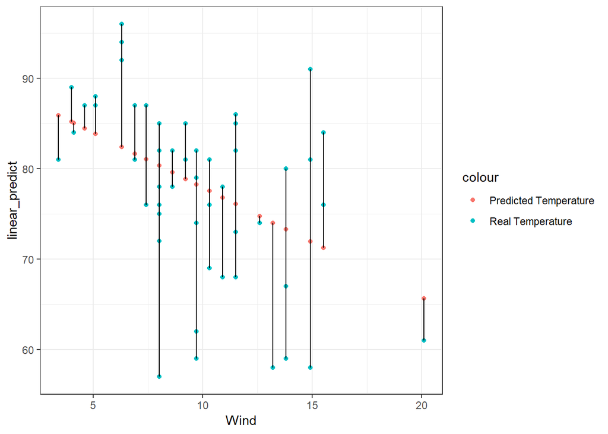

```r
ggplot(data = test_predict_compare) + geom_point(aes(x = Wind, y = linear_predict, col = 'Predicted Temperature')) + geom_point(aes(x = Wind, y = Temp, col = 'Real Temperature')) + geom_segment(aes(x=Wind, y=linear_predict, xend = Wind, yend = Temp)) + theme_bw()
```

4 e) Residuals should be normally distributed. Plot the density of the residuals

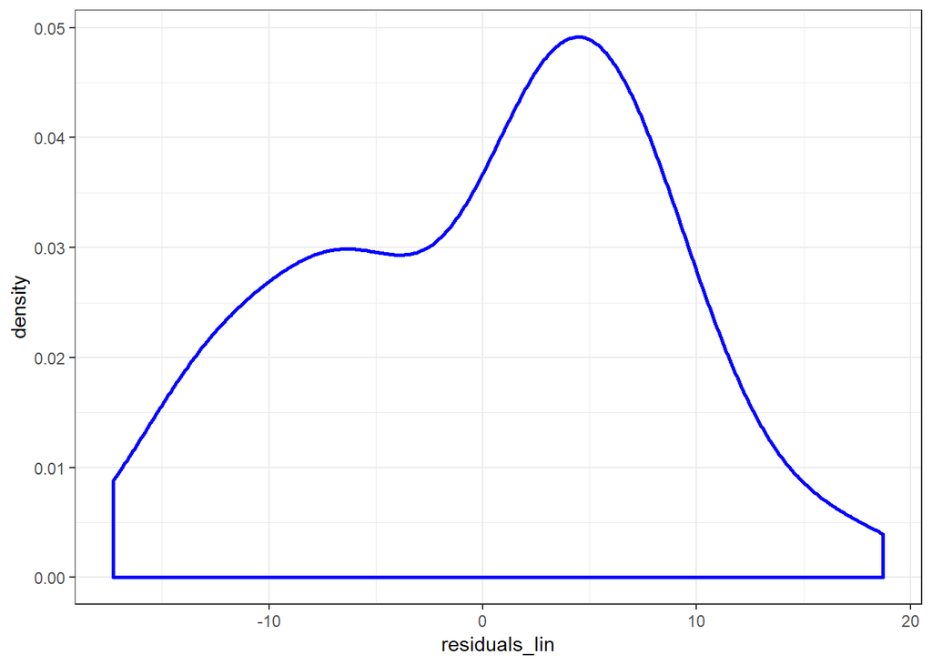

```r
residuals_lin <- residuals(linear_regression)
ggplot(train_regression) + geom_density(aes(residuals_lin), color = 'blue', size = 1) + theme_bw()
```

Next to normal.

4 f) Independent variables and residuals should not be correlated

```r
cor.test(train_regression$Wind, resid(linear_regression))
```

```
##
##  Pearson's product-moment correlation
##
## data:  train_regression$Wind and resid(linear_regression)
## t = 4.3949e-15, df = 99, p-value = 1
## alternative hypothesis: true correlation is not equal to 0
## 95 percent confidence interval:
##  -0.1954393  0.1954393
## sample estimates:
##          cor
## 4.417025e-16
```

Not correlated.

### Linear Regression with Regularization

5. Create a linear model using L1 or L2 regularization to predict Temperature from Wind and Month variables. Plot your predicted values and the real Y values on the same plot.

```r
#L1 Regularization - Lasso Regression
ctrl =  trainControl(method = "boot", 15)
lasso_model <- train(Temp ~ Wind + Month, data = train_regression, method = "lasso", trControl= ctrl)
summary(lasso_model)
```

```
##             Length Class      Mode
## call        4      -none-     call
## actions     3      -none-     list
## allset      2      -none-     numeric
## beta.pure   6      -none-     numeric
## vn          2      -none-     character
## mu          1      -none-     numeric
## normx       2      -none-     numeric
## meanx       2      -none-     numeric
## lambda      1      -none-     numeric
## L1norm      3      -none-     numeric
## penalty     3      -none-     numeric
## df          3      -none-     numeric
## Cp          3      -none-     numeric
## sigma2      1      -none-     numeric
## xNames      2      -none-     character
## problemType 1      -none-     character
## tuneValue   1      data.frame list
## obsLevels   1      -none-     logical
## param       0      -none-     list
```

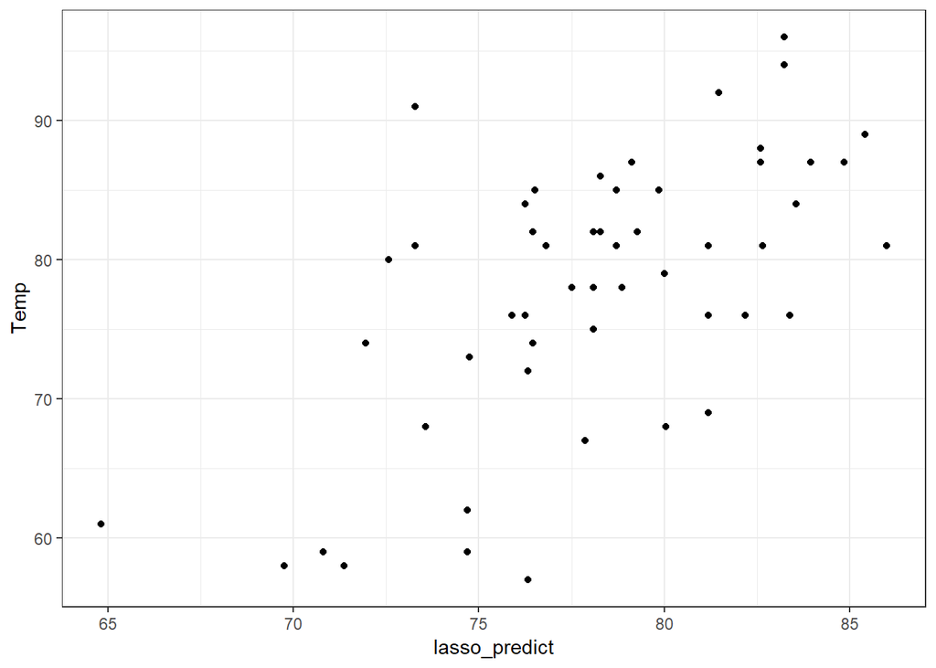

```r
lasso_predict <- predict(lasso_model, newdata = test_regression)
predvstest.l <- cbind(lasso_predict,test_regression)
ggplot(data = predvstest.l) + geom_point(aes(x=lasso_predict, y=Temp)) + theme_bw()
```

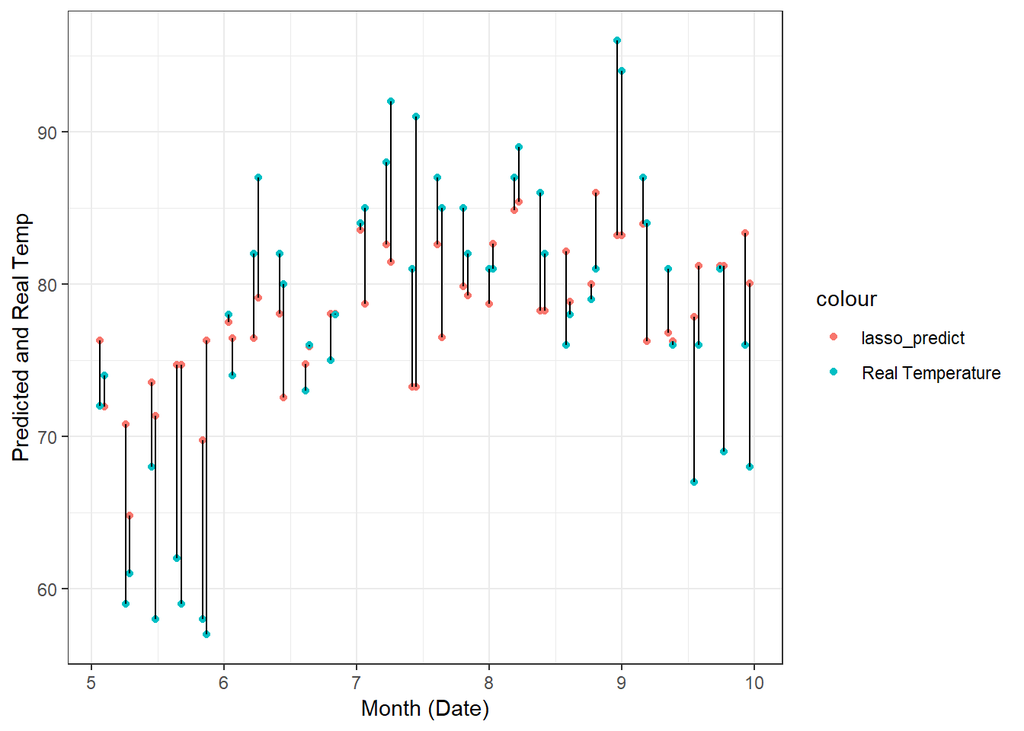

```r
ggplot(data = predvstest.l) + geom_point(aes(x=Month+Day/31, y=lasso_predict, col = 'lasso_predict')) + geom_point(aes(x=Month+Day/31, y=Temp, col = 'Real Temperature')) + geom_segment(aes(x=Month+Day/31, y=lasso_predict, xend = Month+Day/31, yend = Temp)) +xlab("Month (Date)") + ylab("Predicted and Real Temp") + theme_bw()
```

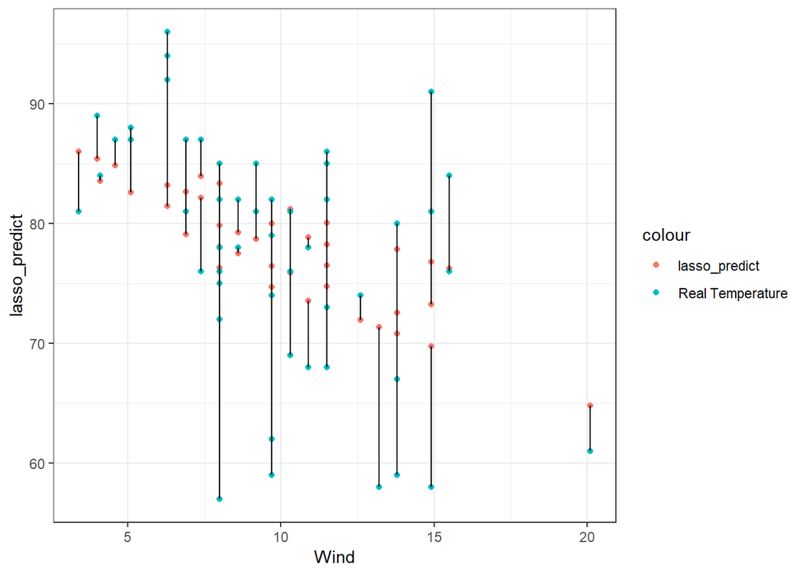

```r
ggplot(data = predvstest.l) + geom_point(aes(x = Wind, y = lasso_predict, col = 'lasso_predict')) + geom_point(aes(x = Wind, y = Temp, col = 'Real Temperature')) + geom_segment(aes(x=Wind, y=lasso_predict, xend = Wind, yend = Temp)) + theme_bw()
```

```r
cor.test(predvstest.l$lasso_predict,predvstest.l$Temp)
```

```
##
##  Pearson's product-moment correlation
##
## data:  predvstest.l$lasso_predict and predvstest.l$Temp
## t = 5.5773, df = 50, p-value = 9.856e-07
## alternative hypothesis: true correlation is not equal to 0
## 95 percent confidence interval:
##  0.4168430 0.7632083
## sample estimates:
##       cor
## 0.6192945
```

```r
#L2 Regularization - Ridge Regression
ridge_model <- train(Temp ~ Wind + Month, data = train_regression, method = "ridge", trControl= ctrl)
summary(ridge_model)
```

```
##             Length Class      Mode
## call        4      -none-     call
## actions     3      -none-     list
## allset      2      -none-     numeric
## beta.pure   6      -none-     numeric
## vn          2      -none-     character
## mu          1      -none-     numeric
## normx       2      -none-     numeric
## meanx       2      -none-     numeric
## lambda      1      -none-     numeric
## L1norm      3      -none-     numeric
## penalty     3      -none-     numeric
## df          3      -none-     numeric
## Cp          3      -none-     numeric
## sigma2      1      -none-     numeric
## xNames      2      -none-     character
## problemType 1      -none-     character
## tuneValue   1      data.frame list
## obsLevels   1      -none-     logical
## param       0      -none-     list
```

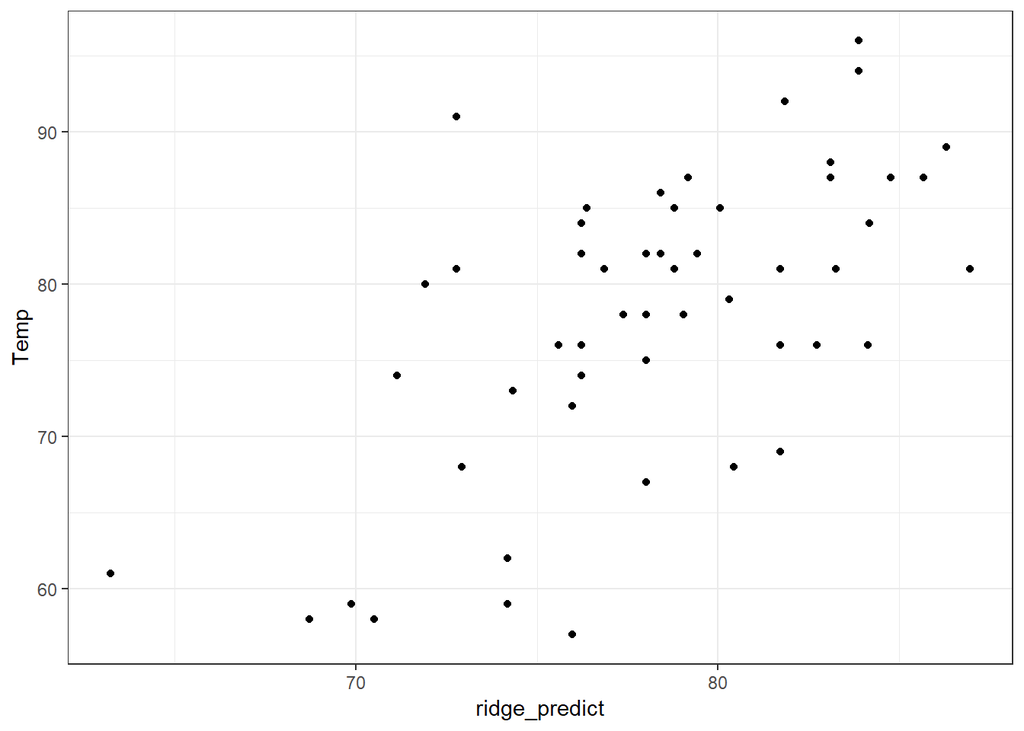

```r
ridge_predict <- predict(ridge_model, newdata = test_regression)
predvstest.r <- cbind(ridge_predict,test_regression)
ggplot(data = predvstest.r) + geom_point(aes(x=ridge_predict, y=Temp)) + theme_bw()
```

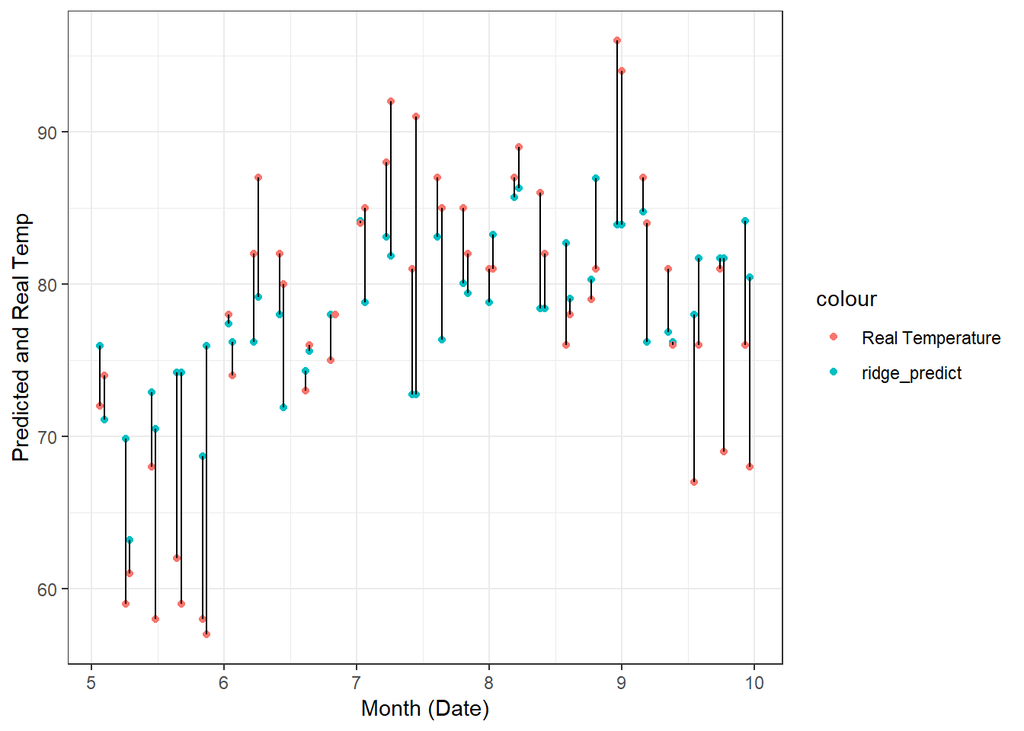

```r
ggplot(data = predvstest.r) + geom_point(aes(x=Month+Day/31, y=ridge_predict, col = 'ridge_predict')) + geom_point(aes(x=Month+Day/31, y=Temp, col = 'Real Temperature')) + geom_segment(aes(x=Month+Day/31, y=ridge_predict, xend = Month+Day/31, yend = Temp)) +xlab("Month (Date)") + ylab("Predicted and Real Temp") + theme_bw()
```

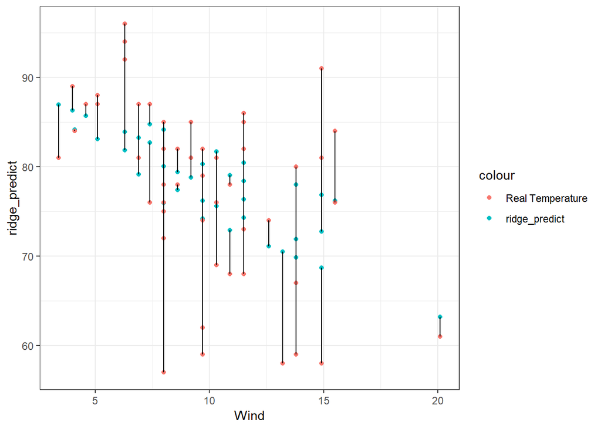

```r
ggplot(data = predvstest.r) + geom_point(aes(x = Wind, y = ridge_predict, col = 'ridge_predict')) + geom_point(aes(x = Wind, y = Temp, col = 'Real Temperature')) + geom_segment(aes(x=Wind, y=ridge_predict, xend = Wind, yend = Temp)) + theme_bw()
```

```r
cor.test(predvstest.r$ridge_predict,predvstest.r$Temp)
```

```
##
##  Pearson's product-moment correlation
##
## data:  predvstest.r$ridge_predict and predvstest.r$Temp
## t = 5.6016, df = 50, p-value = 9.043e-07
## alternative hypothesis: true correlation is not equal to 0
## 95 percent confidence interval:
##  0.4190692 0.7643322
## sample estimates:
##       cor
## 0.6209546
```